# Esempio2_Es4

# 1 TESTO

Il dataset diamanti.csv contiene i dati relativi al peso e al prezzo di un campione di 308 diamanti. Il peso è espresso in carati, mentre il prezzo in dollari di Singapore.

Si risponda ai seguenti quesiti:

1. si costruiscano almeno due modelli alternativi per prevedere il prezzo dei diamanti sulla base del loro peso e si spieghi quale dei modelli considerati sia preferibile;
2. si illustri il modello scelto al punto precedente calcolando un intervallo di previsione al 99% per il prezzo di un diamante con un peso (i) di 0.5 carati e (ii) di 1 carato.

# 2 SOLUZIONE

## 2.1 Punto 1

Leggiamo e visualizziamo i dati:

```r
diamanti <- read.csv("diamanti.csv")
head(diamanti)
```

|  | peso | prezzo |
| --- | --- | --- |
| 1 | 0.30 | 1302 |
| 2 | 0.30 | 1510 |
| 3 | 0.30 | 1510 |
| 4 | 0.30 | 1260 |
| 5 | 0.31 | 1641 |
| 6 | 0.31 | 1555 |

Visualizzo i dati tramite grafico:

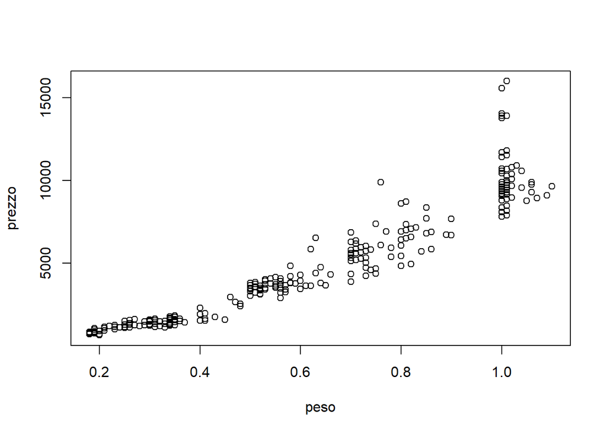

```r
plot(prezzo ~ peso, data = diamanti)
```

Notiamo che il grafico non è di facile interpretazione.

Creo modello di regressione lineare:

```r
mod <- lm(prezzo ~ peso, data = diamanti)
summary(mod)
```

```
##
## Call:
## lm(formula = prezzo ~ peso, data = diamanti)
##
## Residuals:
##     Min      1Q  Median      3Q     Max
## -2264.7  -604.3  -116.1   435.1  6591.5
##
## Coefficients:
##             Estimate Std. Error t value Pr(>|t|)
## (Intercept)  -2298.4      158.5  -14.50   <2e-16 ***
## peso         11598.9      230.1   50.41   <2e-16 ***
## ---
## Signif. codes:  0 '***' 0.001 '**' 0.01 '*' 0.05 '.' 0.1 ' ' 1
##
## Residual standard error: 1118 on 306 degrees of freedom
## Multiple R-squared:  0.8925, Adjusted R-squared:  0.8922
## F-statistic:  2541 on 1 and 306 DF,  p-value: < 2.2e-16
```

Analisi dei residui:

```r
library(car)
```

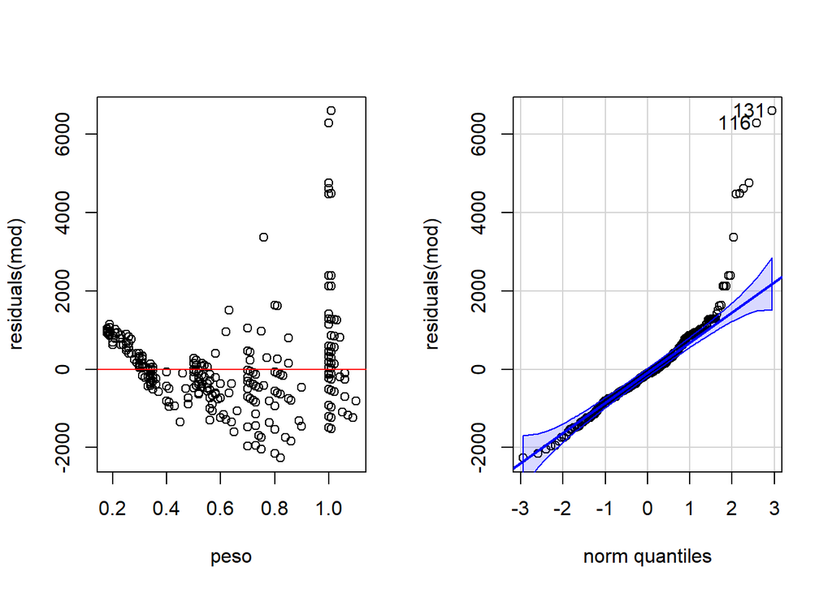

```
## [1] 131 116
```

```r
par(mfrow = c(1, 2))
plot(residuals(mod) ~ peso, data = diamanti)
abline(h = 0, col = "red")
qqPlot(residuals(mod))
```

Dall’analisi dei residui noto che il modello di regressione non è apporpriato. Inoltre il modello porta a stime del prezzo negative.

Provo a trasformare le variabili su scala logaritmica:

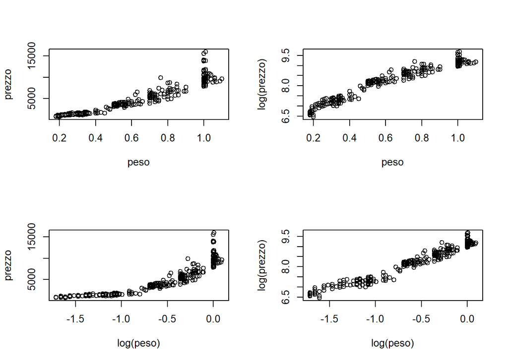

```r
par(mfrow = c(2, 2))
plot(prezzo ~ peso, data = diamanti)
plot(log(prezzo) ~ peso, data = diamanti)
plot(prezzo ~ log(peso), data = diamanti)
plot(log(prezzo) ~ log(peso), data = diamanti)
```

Tra i quattro grafici, il secondo sembra essere il più promettente. Provo a stimare il modello di regressione lineare con le variabili trasformate:

```r
mod_log <- lm(log(prezzo) ~ peso, data = diamanti)
summary(mod_log)
```

```
##
## Call:
## lm(formula = log(prezzo) ~ peso, data = diamanti)
##
## Residuals:
##      Min       1Q   Median       3Q      Max
## -0.55486 -0.16271 -0.00869  0.15522  0.59431
##
## Coefficients:
##             Estimate Std. Error t value Pr(>|t|)
## (Intercept)  6.44488    0.02938  219.40   <2e-16 ***
## peso         2.84155    0.04264   66.64   <2e-16 ***
## ---
## Signif. codes:  0 '***' 0.001 '**' 0.01 '*' 0.05 '.' 0.1 ' ' 1
##
## Residual standard error: 0.2071 on 306 degrees of freedom
## Multiple R-squared:  0.9355, Adjusted R-squared:  0.9353
## F-statistic:  4441 on 1 and 306 DF,  p-value: < 2.2e-16
```

Analisi dei residui:

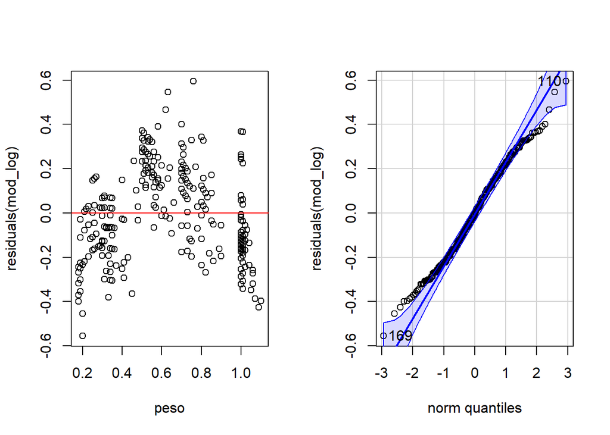

```
## [1] 110 169
```

```r
par(mfrow = c(1, 2))
plot(residuals(mod_log) ~ peso, data = diamanti)
abline(h = 0, col = "red")
qqPlot(residuals(mod_log))
```

Dall’analisi dei residui noto che il modello di regressione non è appropriato, sembra non essere lineare.

Aggiungo un termine quadratico al modello:

```r
mod_quad <- lm(log(prezzo) ~ peso + I(peso^2), data = diamanti)
summary(mod_quad)
```

```
##
## Call:
## lm(formula = log(prezzo) ~ peso + I(peso^2), data = diamanti)
##
## Residuals:
##      Min       1Q   Median       3Q      Max
## -0.45187 -0.08858 -0.00441  0.09685  0.50045
##
## Coefficients:
##             Estimate Std. Error t value Pr(>|t|)
## (Intercept)   5.7806     0.0483  119.68   <2e-16 ***
## peso          5.4368     0.1709   31.81   <2e-16 ***
## I(peso^2)    -2.0501     0.1326  -15.46   <2e-16 ***
## ---
## Signif. codes:  0 '***' 0.001 '**' 0.01 '*' 0.05 '.' 0.1 ' ' 1
##
## Residual standard error: 0.1553 on 305 degrees of freedom
## Multiple R-squared:  0.9639, Adjusted R-squared:  0.9636
## F-statistic:  4066 on 2 and 305 DF,  p-value: < 2.2e-16
```

Il modello al quadratro ha un valore di $R^2$ aggiustato maggiore rispetto al modello lineare. Sembra essere quindi migliore.

Analisi dei residui:

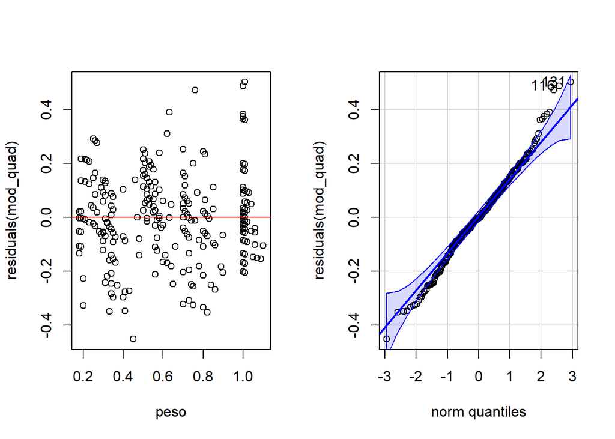

```
## [1] 131 116
```

```r
par(mfrow = c(1, 2))
plot(residuals(mod_quad) ~ peso, data = diamanti)
abline(h = 0, col = "red")
qqPlot(residuals(mod_quad))
```

Dall’analisi dei residui noto che il modello è appropriato anche se ho delle sottostime e sovrastime alle code.

Il modello quadratico spiega il 96% della variabilità del prezzo dei diamanti su scala logaritmica.

Visualizziamo il modello stimato:

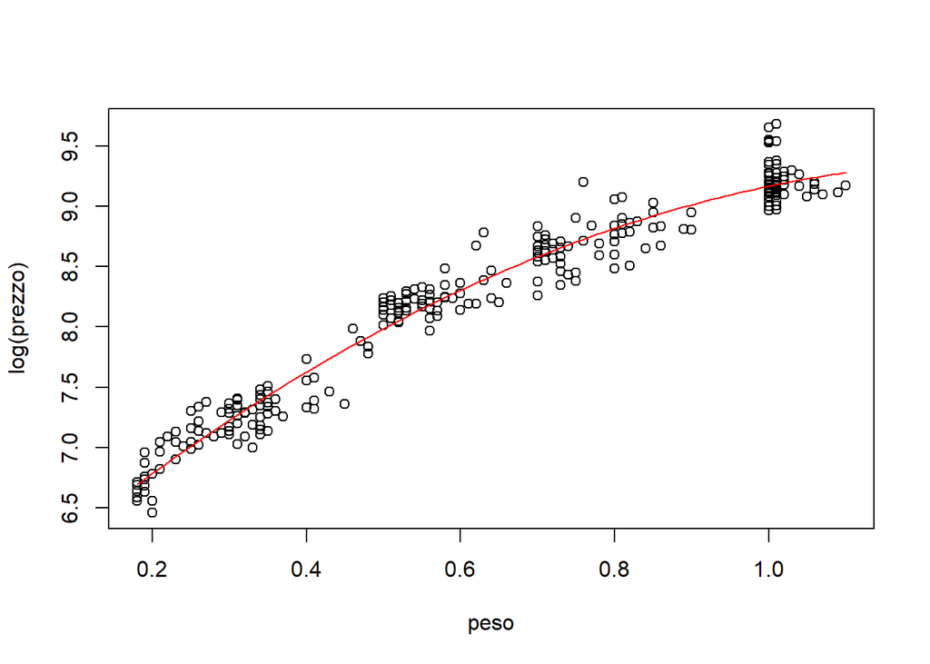

```r
par(mfrow = c(1, 1))
plot(log(prezzo) ~ peso, data = diamanti)
curve(coef(mod_quad)[1] + coef(mod_quad)[2] * x + coef(mod_quad)[3] * x^2, from = min(diamanti$peso), to = max(diamanti$peso), add = TRUE, col = "red")
```

## 2.2 Punto 2

Calcoliamo l’intervallo di previsione al 99% per il prezzo di un diamante con peso di 0.5 carati:

```r
pred <- predict(mod_quad, newdata = data.frame(peso = 0.5), interval = "prediction", level = 0.99)
exp(pred)
```

```
##        fit      lwr      upr
## 1 2940.795 1963.546 4404.418
```

Calcoliamo l’intervallo di previsione al 99% per il prezzo di un diamante con peso di 1 carato:

```r
pred <- predict(mod_quad, newdata = data.frame(peso = 1), interval = "prediction", level = 0.99)
exp(pred)
```

```
##        fit      lwr      upr
## 1 9578.124 6388.853 14359.46
```